# EasyVisa

#### Observations on outliers

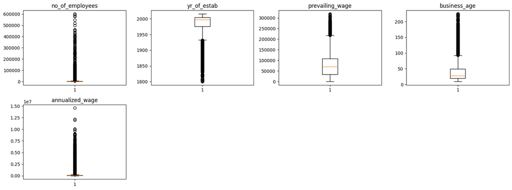

```python
# analyzing outliers
plot_numeric_outliers_boxplots(df)
```

Observations:

## Data Pre-processing

- Objective is to predict visa certification
- Need to encode some columns
- There are no missing values
- Although there are outliers, none of the outliers are deemed invalid. We will not drop any of them
- Split the Data into Train and Test

```python
# Encode 'case_status' to binary: 1 = Certified, 0 = Denied
df['case_status'] = df['case_status'].apply(lambda x: 1 if x == 'Certified' else 0)
print(df['case_status'].value_counts())
```

```
case_status
1    17001
0     8446
Name: count, dtype: int64
```

```python
# Binary label encoding for binary categorical columns
binary_mappings = {
    'has_job_experience': {'Y': 1, 'N': 0},
    'requires_job_training': {'Y': 1, 'N': 0},
    'full_time_position': {'Y': 1, 'N': 0}
}
for col, mapping in binary_mappings.items():
    df[col] = df[col].map(mapping)
```

```python
# Ordinal encoding for education_of_employee
education_order = {
    'High School': 0,
    "Bachelor's": 1,
    "Master's": 2,
    'Doctorate': 3
}
df['education_of_employee'] = df['education_of_employee'].map(education_order)
```

```python
# Split features and target
X = df.drop('case_status', axis=1)
y = df['case_status']
```

```python
# One-hot encode remaining categorical variables
X = pd.get_dummies(X, columns=['continent', 'region_of_employment', 'unit_of_wage'], drop_first=True)
```

```python
# Split the data into training and validation sets (70% train, 30% validation)
# Stratify ensures the target class distribution is maintained
X_train, X_val, y_train, y_val = train_test_split(
    X, y, test_size=0.30, random_state=1, stratify=y
)
```

```python
# Split the validation set into validation and test sets (10% of original data goes to test set)
# Stratify ensures class balance is maintained
X_val, X_test, y_val, y_test = train_test_split(
    X_val, y_val, test_size=0.10, random_state=1, stratify=y_val
)
```

```python
# ✅ Print shape of each dataset
print("Shape of Training set     :", X_train.shape)
print("Shape of Validation set   :", X_val.shape)
print("Shape of Test set         :", X_test.shape)

# ✅ Print percentage of each class in the target column for each dataset
print("\nClass distribution in Training set:")
print(y_train.value_counts(normalize=True).rename("proportion").to_frame())

print("\nClass distribution in Validation set:")
print(y_val.value_counts(normalize=True).rename("proportion").to_frame())

print("\nClass distribution in Test set:")
print(y_test.value_counts(normalize=True).rename("proportion").to_frame())
```

```
Shape of Training set     : (17812, 21)
Shape of Validation set   : (6871, 21)
Shape of Test set         : (764, 21)

Class distribution in Training set:
             proportion
case_status
1              0.668089
0              0.331911

Class distribution in Validation set:
             proportion
case_status
1              0.668171
0              0.331829

Class distribution in Test set:
             proportion
case_status
1              0.667539
0              0.332461
```

## Model Building

### Modeling & Metrics Functions

```python
from sklearn.metrics import accuracy_score, precision_score, recall_score, f1_score, confusion_matrix, classification_report

def evaluate_classification_model(model, X, y_true, average='binary'):
    """
    Evaluate the performance of a classification model using key metrics.

    Parameters:
        model: Trained classifier with a .predict() method
        X (DataFrame or array): Feature set to predict on
        y_true (array-like): True target labels
        average (str): Type of averaging for multi-class (use 'binary' for binary classification)

    Returns:
        metrics_dict (dict): Dictionary of computed evaluation metrics
    """

    # Make predictions
    y_pred = model.predict(X)

    # Calculate metrics
    metrics_dict = {
        'Accuracy': accuracy_score(y_true, y_pred),
        'Precision': precision_score(y_true, y_pred, average=average),
        'Recall': recall_score(y_true, y_pred, average=average),
        'F1 Score': f1_score(y_true, y_pred, average=average),
        'Confusion Matrix': confusion_matrix(y_true, y_pred)
    }

    # Print report
    print("\nClassification Report:")
    print(classification_report(y_true, y_pred))

    print("\nEvaluation Metrics:")
    for key, value in metrics_dict.items():
        if key != 'Confusion Matrix':
            print(f"{key}: {value:.4f}")
        else:
            print(f"{key}:\n{value}")

    return metrics_dict

def plot_confusion_matrix(model, X, y_true, labels=None):
    """
    Plot the confusion matrix for a classification model as a heatmap.

    Parameters:
        model: Trained classification model
        X: Feature set for prediction
        y_true: True target values
        labels (list): Optional list of class labels (e.g., ['Denied', 'Certified'])
    """
    y_pred = model.predict(X)
    cm = confusion_matrix(y_true, y_pred)

    plt.figure(figsize=(6, 4))
    sns.heatmap(cm, annot=True, fmt='d', cmap='Blues',
                xticklabels=labels, yticklabels=labels)
    plt.title('Confusion Matrix')
    plt.xlabel('Predicted')
    plt.ylabel('Actual')
    plt.show()

def plot_roc_curve(model, X, y_true):
    """
    Plot the ROC curve for a binary classification model.

    Parameters:
        model: Trained classifier with predict_proba or decision_function
        X: Feature set to predict on
        y_true: True target labels
    """
    # Get predicted probabilities (assumes binary classification)
    if hasattr(model, "predict_proba"):
        y_scores = model.predict_proba(X)[:, 1]
    else:
        y_scores = model.decision_function(X)

    fpr, tpr, thresholds = roc_curve(y_true, y_scores)
    auc = roc_auc_score(y_true, y_scores)

    plt.figure(figsize=(6, 4))
    plt.plot(fpr, tpr, label=f"AUC = {auc:.4f}")
    plt.plot([0, 1], [0, 1], linestyle='--', color='gray')
    plt.xlabel("False Positive Rate")
    plt.ylabel("True Positive Rate")
    plt.title("ROC Curve")
    plt.legend()
    plt.grid(True)
    plt.show()

def plot_model_comparison(names, results, title="Model Comparison - F1 Score (CV)"):
    """
    Plot a bar chart showing mean F1 scores with standard deviation error bars.
    """
    import numpy as np
    import matplotlib.pyplot as plt

    mean_scores = np.array([np.mean(r) for r in results])
    std_scores = np.array([np.std(r) for r in results])

    plt.figure(figsize=(10, 6))
    plt.bar(names, mean_scores, yerr=std_scores, capsize=5, color='skyblue', edgecolor='black')
    plt.ylabel("Mean F1 Score")
    plt.title(title)
    plt.ylim(0, 1)  # F1 score is between 0 and 1
    plt.xticks(rotation=45)
    plt.tight_layout()
    plt.show()
```

### Model Evaluation Criterion

Our objective is to build an optimized classification model to predict visa approval: `case_status` as **Certified** or **Denied**

- The dataset has moderate class imbalance (e.g., ~67% Certified vs 33% Denied).
- We desire both:
  - Precision (avoiding false positives: approving unqualified applications)
  - Recall (avoiding false negatives: missing good candidates)

F1 Score balances both, making it ideal when both types of errors matter.

**We are now done with pre-processing and evaluation criterion, so let's start building the model.**

### Model building with original data

```python
# Initialize model list
models = []

# Append models for evaluation
models.append(("Bagging", BaggingClassifier(random_state=1)))
models.append(("Random Forest", RandomForestClassifier(random_state=1)))
models.append(("GBM", GradientBoostingClassifier(random_state=1)))
models.append(("Adaboost", AdaBoostClassifier(random_state=1)))
models.append(("XGBoost", XGBClassifier(random_state=1, eval_metric="logloss")))
models.append(("Decision Tree", DecisionTreeClassifier(random_state=1)))

# Initialize storage for results
results_original = []
names_original = []

print("Evaluating models on original data...\n")

for name, model in models:
    score = cross_val_score(model, X_train, y_train, cv=5, scoring='f1')
    results_original.append(score)
    names_original.append(name)
    print(f"{name}: Mean F1 = {score.mean():.4f}, Std = {score.std():.4f}")
```

```
Evaluating models on original data...

Bagging: Mean F1 = 0.7754, Std = 0.0054
Random Forest: Mean F1 = 0.8056, Std = 0.0049
GBM: Mean F1 = 0.8237, Std = 0.0024
Adaboost: Mean F1 = 0.8184, Std = 0.0037
XGBoost: Mean F1 = 0.8071, Std = 0.0020
Decision Tree: Mean F1 = 0.7416, Std = 0.0037
```

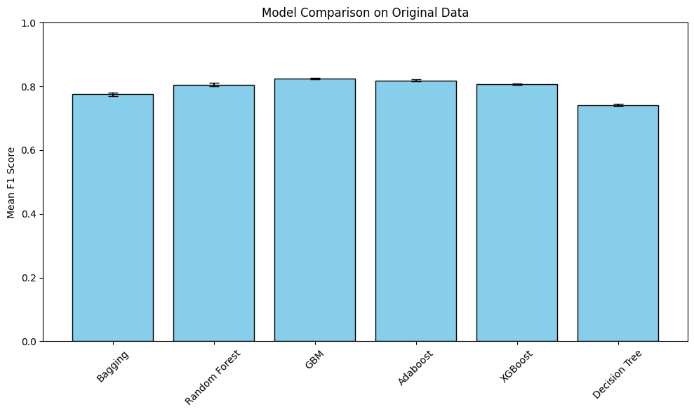

```python
# compare models on original data
plot_model_comparison(names_original, results_original, title="Model Comparison on Original Data")
```

Observations:

- **Gradient Boosting** (GBM) yielded the highest mean F1 score of 0.0.8237, with a low standard deviation (±0.0024), indicating consistently strong performance.
- **Adaboost** yielded the second highest mean F1 score of 0.8184, slightly below Gradient Boosting.
- **XGBoost** followed closely with a mean F1 score of 0.8071, and the lowest variability (±0.0020), suggesting it is also a very stable model.
- **Random Forest** achieved 0.8056, while **Bagging** trailed at 0.7754.
- **Decision Tree** had the lowest score at 0.7416, reflecting its tendency to overfit when used alone.

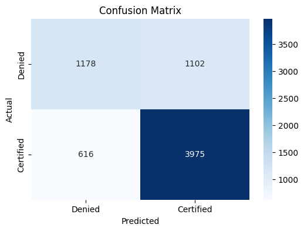

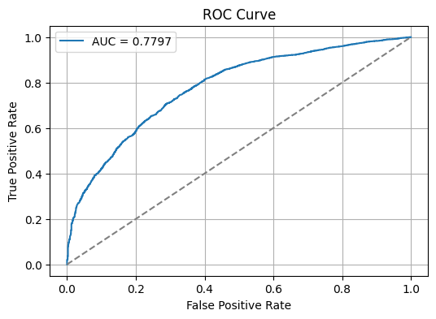

```python
# Fit the best model (Gradient Boosting) on the training data
best_model = GradientBoostingClassifier(random_state=1)
best_model.fit(X_train, y_train)

# Evaluate on validation set
plot_confusion_matrix(best_model, X_val, y_val, labels=["Denied", "Certified"])
plot_roc_curve(best_model, X_val, y_val)
```

Observations:

- True Positives (Certified correctly): 3,975
- True Negatives (Denied correctly): 1,178
- False Positives (Denied incorrectly marked as Certified): 1,102
- False Negatives (Certified incorrectly marked as Denied): 616

The model is more confident in correctly identifying Certified cases than Denied ones.

### Model Building with oversampled data

```python
# Apply SMOTE to the training set
smote = SMOTE(random_state=1)
X_train_over, y_train_over = smote.fit_resample(X_train, y_train)

# Check new class distribution
print("After SMOTE Oversampling:")
print(y_train_over.value_counts())
```

```
After SMOTE Oversampling:
case_status
1    11900
0    11900
Name: count, dtype: int64
```

```python
# Initialize storage for results
results_oversampled = []
names_oversampled = []

print("\n Evaluating models on oversampled data...\n")
for name, model in models:
    score = cross_val_score(model, X_train_over, y_train_over, cv=5, scoring='f1')
    results_oversampled.append(score)
    names_oversampled.append(name)
    print(f"{name}: Mean F1 = {score.mean():.4f}, Std = {score.std():.4f}")
```

```
 Evaluating models on oversampled data...

Bagging: Mean F1 = 0.7648, Std = 0.0494
Random Forest: Mean F1 = 0.7978, Std = 0.0653
GBM: Mean F1 = 0.8083, Std = 0.0700
Adaboost: Mean F1 = 0.7782, Std = 0.0647
XGBoost: Mean F1 = 0.8043, Std = 0.0734
Decision Tree: Mean F1 = 0.7327, Std = 0.0583
```

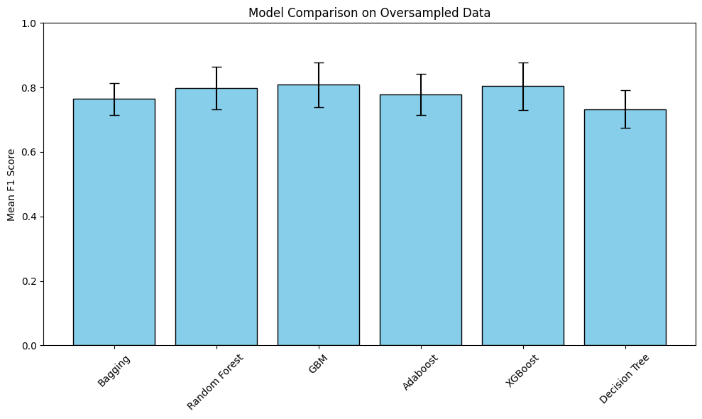

```python
# compare models on oversampled data
plot_model_comparison(names_oversampled, results_oversampled, title="Model Comparison on Oversampled Data")
```

Observations:

Balanced Data

Model Performance

- Gradient Boosting (GBM) continues to outperform other models, maintaining the highest mean F1 score.
- XGBoost and Random Forest closely follow GBM, with very comparable performance.
- Decision Tree remains the weakest performer, even with oversampling.

Summary:

**We should validate this on the actual confusion matrix next.**

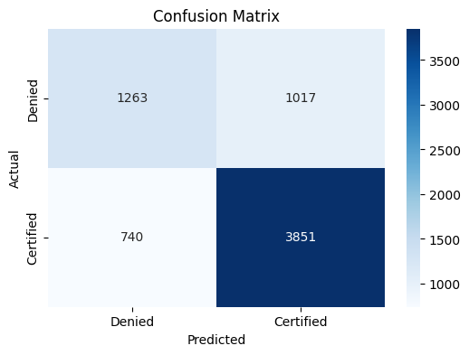

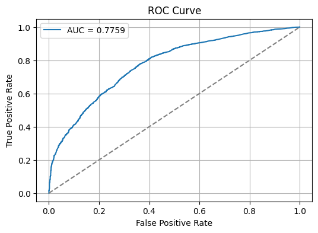

```python
# Fit Gradient Boosting on the oversampled training data
gbm_over = GradientBoostingClassifier(random_state=1)
gbm_over.fit(X_train_over, y_train_over)

# Evaluate on validation set
plot_confusion_matrix(gbm_over, X_val, y_val, labels=["Denied", "Certified"])
plot_roc_curve(gbm_over, X_val, y_val)
```

Observations:

- True Positives (Certified → Certified): 3,851
- True Negatives (Denied → Denied): 1,263
- False Positives (Denied → Certified): 1,017
- False Negatives (Certified → Denied): 740

Oversampling using SMOTE and then training Gradient Boosting enhanced class sensitivity, especially improving the detection of "Denied" applications. Given the business objective of fair and balanced visa recommendation, this model may be a better choice for deployment compared to the one trained on original data alone.

### Model Building with undersampled data

```python
# Apply Random Undersampling to the training set (do not apply to val or test)
rus = RandomUnderSampler(random_state=1)
X_train_under, y_train_under = rus.fit_resample(X_train, y_train)

# Check class distribution after undersampling
print("After Undersampling:")
print(y_train_under.value_counts())
```

```
After Undersampling:
case_status
0    5912
1    5912
Name: count, dtype: int64
```

```python
# Reuse the same models list
results_undersampled = []
names_undersampled = []

print("\n Evaluating models on undersampled data...\n")
for name, model in models:
    score = cross_val_score(model, X_train_under, y_train_under, cv=5, scoring='f1')
    results_undersampled.append(score)
    names_undersampled.append(name)
    print(f"{name}: Mean F1 = {score.mean():.4f}, Std = {score.std():.4f}")
```

```
 Evaluating models on undersampled data...

Bagging: Mean F1 = 0.6349, Std = 0.0094
Random Forest: Mean F1 = 0.6809, Std = 0.0121
GBM: Mean F1 = 0.7058, Std = 0.0089
Adaboost: Mean F1 = 0.6939, Std = 0.0097
XGBoost: Mean F1 = 0.6828, Std = 0.0077
Decision Tree: Mean F1 = 0.6223, Std = 0.0074
```

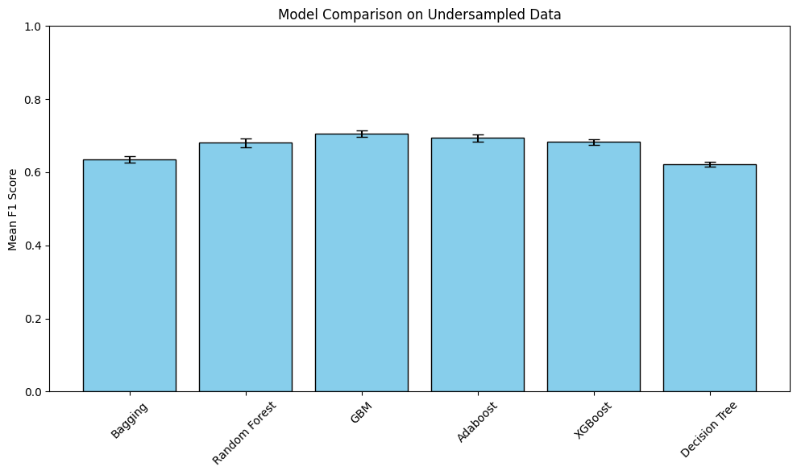

```python
# compare models on oversampled data
plot_model_comparison(names_undersampled, results_undersampled, title="Model Comparison on Undersampled Data")
```

Observations:

- Among all models trained on the undersampled dataset, Gradient Boosting (GBM) achieved the highest mean F1-score of 0.7058, followed closely by AdaBoost (0.6939) and XGBoost (0.6828).
- Random Forest and Bagging models lag behind, with mean F1-scores of 0.6809 and 0.6349, respectively.
- Decision Tree performs the weakest, with a mean F1-score of 0.6223.
- Across the board, F1-scores are lower on undersampled data compared to both original and oversampled datasets.
- Standard deviations are generally low (≈ 0.007–0.012), suggesting consistent performance across cross-validation folds, despite smaller data volume.

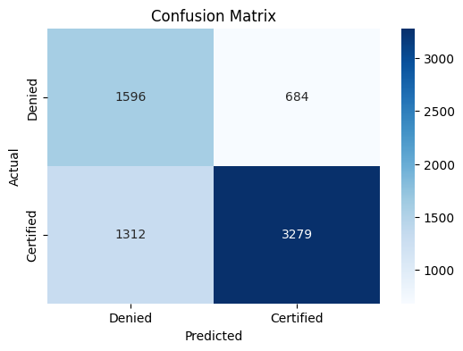

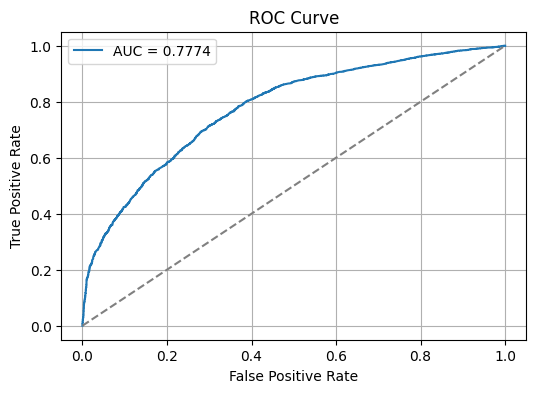

```python
# Fit Gradient Boosting on the undersampled training data
gbm_under = GradientBoostingClassifier(random_state=1)
gbm_under.fit(X_train_under, y_train_under)

# Evaluate on validation set
plot_confusion_matrix(gbm_under, X_val, y_val, labels=["Denied", "Certified"])
plot_roc_curve(gbm_under, X_val, y_val)
```

Observations:

- The model correctly predicted 1,596 Denied and 3,279 Certified applications.
- It misclassified 684 Denied as Certified and 1,312 Certified as Denied.
- The model shows a stronger recall for Denied cases compared to oversampling, suggesting better balance in class predictions, though at a cost of more false negatives.

## Hyperparameter Tuning

### Tuning AdaBoost using oversampled data

```python
# Define AdaBoost model
ada = AdaBoostClassifier(random_state=1)

# Define hyperparameter grid
param_grid = {
    'n_estimators': [50, 100, 150],
    'learning_rate': [0.01, 0.1, 1.0]
}

# Setup GridSearchCV
grid_search = GridSearchCV(
    estimator=ada,
    param_grid=param_grid,
    scoring='f1',
    cv=5,
    n_jobs=-1,
    verbose=1
)

# Fit the grid search on the oversampled training set
grid_search.fit(X_train_over, y_train_over)

# Print best parameters and best score
print("Best Parameters:", grid_search.best_params_)
print("Best F1 Score from CV:", grid_search.best_score_)
```

```
Fitting 5 folds for each of 9 candidates, totalling 45 fits
Best Parameters: {'learning_rate': 1.0, 'n_estimators': 150}
Best F1 Score from CV: 0.792055111356158
```

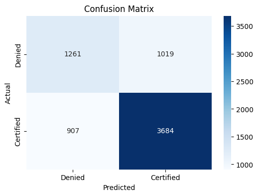

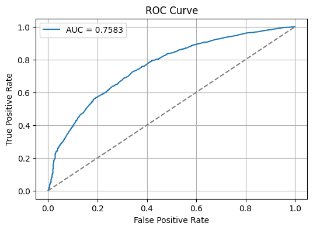

```python
# Get the best estimator from GridSearchCV
best_ada = grid_search.best_estimator_

# Fit the best model on the oversampled training set again (optional but safe)
best_ada.fit(X_train_over, y_train_over)

# Confusion Matrix
plot_confusion_matrix(best_ada, X_val, y_val, labels=["Denied", "Certified"])

# ROC Curve
plot_roc_curve(best_ada, X_val, y_val)
```

Observations:

- True Positives (Certified correctly predicted): 3,684
- True Negatives (Denied correctly predicted): 1,261
- False Positives (Denied incorrectly predicted as Certified): 1,019
- False Negatives (Certified incorrectly predicted as Denied): 907
- The tuned model slightly favors predicting Certified over Denied, evident from the higher number of false positives compared to false negatives.

Hyperparameter Tuning Impact:

- The best parameters found were: n_estimators = 150 and learning_rate = 1.0
- These settings gave an F1 Score of ~0.793 during cross-validation, a competitive performance.

Model Performance Insight:

- Compared to earlier models, the tuned AdaBoost shows balanced performance, but with a slight increase in false positives.
- This model may be more favorable in cases where approving qualified candidates is prioritized, even at the cost of some incorrect approvals.

### Tuning Random forest using undersampled data

```
Fitting 5 folds for each of 18 candidates, totalling 90 fits
Best Parameters: {'max_depth': 10, 'min_samples_split': 2, 'n_estimators': 50}
Best F1 Score from CV: 0.7114909319352185
```

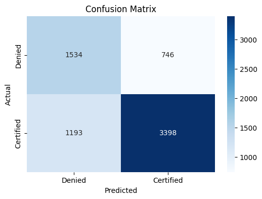

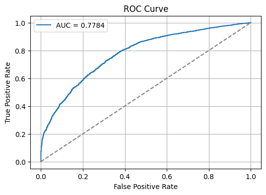

```python
# Define Random Forest model
rf = RandomForestClassifier(random_state=1)

# Define hyperparameter grid
param_grid = {
    'n_estimators': [50, 100, 150],
    'max_depth': [None, 10, 20],
    'min_samples_split': [2, 5],
}

# Setup GridSearchCV
grid_search_rf = GridSearchCV(
    estimator=rf,
    param_grid=param_grid,
    scoring='f1',
    cv=5,
    n_jobs=-1,
    verbose=1
)

# Fit the grid search on the undersampled training set
grid_search_rf.fit(X_train_under, y_train_under)

# Print best parameters and score
print("Best Parameters:", grid_search_rf.best_params_)
print("Best F1 Score from CV:", grid_search_rf.best_score_)

# Get best estimator
best_rf = grid_search_rf.best_estimator_

# Fit the best model on the training set (optional if already done internally)
best_rf.fit(X_train_under, y_train_under)

# Evaluate on the validation set
plot_confusion_matrix(best_rf, X_val, y_val, labels=["Denied", "Certified"])
plot_roc_curve(best_rf, X_val, y_val)
```

Observations:

- True Positives (Certified correctly predicted): 3,398
- True Negatives (Denied correctly predicted): 1,534
- False Positives (Denied predicted as Certified): 746
- False Negatives (Certified predicted as Denied): 1,193

Hyperparameter Tuning Impact:

- n_estimators = 50
- max_depth = 10
- min_samples_split = 2

These settings resulted in a best cross-validated F1 score of approximately 0.7115 on the training folds.

Model Performance Insight:

- The model tends to have a higher false negative rate compared to false positives, meaning more Certified cases are being incorrectly predicted as Denied.